# Bellabeat Capstone Project

Crystal Norman

2023-03-26

# Introduction

Hello my name is Crystal Norman, I’m a Junior Data Analyst who recently completed the [**Google Data Analytics Professional Course**](https://www.coursera.org/professional-certificates/google-data-analytics) and this is my Capstone project. I chose to take the course to gain an overall view of the different tools available in a Data Analyst career.

The skills I acquired while taking the course are:

**Soft skills**

- Analytical thinking
- Pattern recognition
- Effective questioning

**Hard skills**

- Spreadsheets (Google Sheet & Excel)
- SQL (PostGreSQL)
- Tableau
- Power BI
- R Programming

# About the Company

Urška Sršen and Sando Mur founded Bellabeat, a high-tech company that manufactures health-focused smart products.Sršen used her background as an artist to develop technology that informs and inspires women around the world. Collecting data on activity, sleep, stress, and reproductive health has allowed Bellabeat to empower women with knowledge about their own health and habits. Since it was founded in 2013, Bellabeat has grown rapidly and quickly positioned itself as a tech-driven wellness company for women.

## 1. Business Task

The business task is to analyze Bellabeat user behavior and engagement patterns to identify trends and areas of improvement. The ultimate goal is to use this knowledge to develop new products and services that better meet the needs and expectations of the target audience, ultimately driving growth and increasing revenue for the brand. Business recommendations will be delivered to the stakeholders Urška Sršen, Sando Mur, and the Bellabeat marketing analytics team by the conclusion of the project.

## 3. Processing the Data

*I chose to use the language program R because I’m working with a large data set that contains multiple csv files.*

### 3.1 Steps taken to perform the cleaning process

#### Setup the packages in R for cleaning, analysis, and visualizations

```r
install.packages("tidyverse")
install.packages("dplyr")
install.packages("skimr")
install.packages("janitor")
```

#### Load the Libraries

```r
library(tidyverse)
library(dplyr)
library(tidyr)
library(readr)
library(lubridate)
library(skimr)
library(janitor)
```

#### Import the dataset

```r
dailyActivity <- read_csv("dailyActivity_merged.csv")
sleepDay <- read_csv("sleepDay_merged.csv")
```

#### Previewing Dataset

```r
colnames(dailyActivity)
```

```
##  [1] "Id"                       "ActivityDate"
##  [3] "TotalSteps"               "TotalDistance"
##  [5] "TrackerDistance"          "LoggedActivitiesDistance"
##  [7] "VeryActiveDistance"       "ModeratelyActiveDistance"
##  [9] "LightActiveDistance"      "SedentaryActiveDistance"
## [11] "VeryActiveMinutes"        "FairlyActiveMinutes"
## [13] "LightlyActiveMinutes"     "SedentaryMinutes"
## [15] "Calories"
```

```r
str(dailyActivity)
```

```
## spc_tbl_ [940 × 15] (S3: spec_tbl_df/tbl_df/tbl/data.frame)
##  $ Id                      : num [1:940] 1.5e+09 1.5e+09 1.5e+09 1.5e+09 1.5e+09 ...
##  $ ActivityDate            : chr [1:940] "4/12/2016" "4/13/2016" "4/14/2016" "4/15/2016" ...
##  $ TotalSteps              : num [1:940] 13162 10735 10460 9762 12669 ...
##  $ TotalDistance           : num [1:940] 8.5 6.97 6.74 6.28 8.16 ...
##  $ TrackerDistance         : num [1:940] 8.5 6.97 6.74 6.28 8.16 ...
##  $ LoggedActivitiesDistance: num [1:940] 0 0 0 0 0 0 0 0 0 0 ...
##  $ VeryActiveDistance      : num [1:940] 1.88 1.57 2.44 2.14 2.71 ...
##  $ ModeratelyActiveDistance: num [1:940] 0.55 0.69 0.4 1.26 0.41 ...
##  $ LightActiveDistance     : num [1:940] 6.06 4.71 3.91 2.83 5.04 ...
##  $ SedentaryActiveDistance : num [1:940] 0 0 0 0 0 0 0 0 0 0 ...
##  $ VeryActiveMinutes       : num [1:940] 25 21 30 29 36 38 42 50 28 19 ...
##  $ FairlyActiveMinutes     : num [1:940] 13 19 11 34 10 20 16 31 12 8 ...
##  $ LightlyActiveMinutes    : num [1:940] 328 217 181 209 221 164 233 264 205 211 ...
##  $ SedentaryMinutes        : num [1:940] 728 776 1218 726 773 ...
##  $ Calories                : num [1:940] 1985 1797 1776 1745 1863 ...
##  - attr(*, "spec")=
##   .. cols(
##   ..   Id = col_double(),
##   ..   ActivityDate = col_character(),
##   ..   TotalSteps = col_double(),
##   ..   TotalDistance = col_double(),
##   ..   TrackerDistance = col_double(),
##   ..   LoggedActivitiesDistance = col_double(),
##   ..   VeryActiveDistance = col_double(),
##   ..   ModeratelyActiveDistance = col_double(),
##   ..   LightActiveDistance = col_double(),
##   ..   SedentaryActiveDistance = col_double(),
##   ..   VeryActiveMinutes = col_double(),
##   ..   FairlyActiveMinutes = col_double(),
##   ..   LightlyActiveMinutes = col_double(),
##   ..   SedentaryMinutes = col_double(),
##   ..   Calories = col_double()
##   .. )
##  - attr(*, "problems")=<externalptr>
```

```r
head(dailyActivity)
```

| Id | ActivityDate | TotalSteps | TotalDistance | TrackerDistance | LoggedActivitiesDistance | VeryActiveDistance | ModeratelyActiveDistance | LightActiveDistance | SedentaryActiveDistance | VeryActiveMinutes | FairlyActiveMinutes | LightlyActiveMinutes | SedentaryMinutes | Calories |
| --- | --- | --- | --- | --- | --- | --- | --- | --- | --- | --- | --- | --- | --- | --- |
| 1503960366 | 4/12/2016 | 13162 | 8.50 | 8.50 | 0 | 1.88 | 0.55 | 6.06 | 0 | 25 | 13 | 328 | 728 | 1985 |
| 1503960366 | 4/13/2016 | 10735 | 6.97 | 6.97 | 0 | 1.57 | 0.69 | 4.71 | 0 | 21 | 19 | 217 | 776 | 1797 |
| 1503960366 | 4/14/2016 | 10460 | 6.74 | 6.74 | 0 | 2.44 | 0.40 | 3.91 | 0 | 30 | 11 | 181 | 1218 | 1776 |
| 1503960366 | 4/15/2016 | 9762 | 6.28 | 6.28 | 0 | 2.14 | 1.26 | 2.83 | 0 | 29 | 34 | 209 | 726 | 1745 |
| 1503960366 | 4/16/2016 | 12669 | 8.16 | 8.16 | 0 | 2.71 | 0.41 | 5.04 | 0 | 36 | 10 | 221 | 773 | 1863 |
| 1503960366 | 4/17/2016 | 9705 | 6.48 | 6.48 | 0 | 3.19 | 0.78 | 2.51 | 0 | 38 | 20 | 164 | 539 | 1728 |

```r
colnames(sleepDay)
```

```
## [1] "Id"                 "SleepDay"           "TotalSleepRecords"
## [4] "TotalMinutesAsleep" "TotalTimeInBed"
```

```r
str(sleepDay)
```

```
## spc_tbl_ [413 × 5] (S3: spec_tbl_df/tbl_df/tbl/data.frame)
##  $ Id                : num [1:413] 1.5e+09 1.5e+09 1.5e+09 1.5e+09 1.5e+09 ...
##  $ SleepDay          : chr [1:413] "4/12/2016 12:00:00 AM" "4/13/2016 12:00:00 AM" "4/15/2016 12:00:00 AM" "4/16/2016 12:00:00 AM" ...
##  $ TotalSleepRecords : num [1:413] 1 2 1 2 1 1 1 1 1 1 ...
##  $ TotalMinutesAsleep: num [1:413] 327 384 412 340 700 304 360 325 361 430 ...
##  $ TotalTimeInBed    : num [1:413] 346 407 442 367 712 320 377 364 384 449 ...
##  - attr(*, "spec")=
##   .. cols(
##   ..   Id = col_double(),
##   ..   SleepDay = col_character(),
##   ..   TotalSleepRecords = col_double(),
##   ..   TotalMinutesAsleep = col_double(),
##   ..   TotalTimeInBed = col_double()
##   .. )
##  - attr(*, "problems")=<externalptr>
```

```r
head(sleepDay)
```

| Id | SleepDay | TotalSleepRecords | TotalMinutesAsleep | TotalTimeInBed |
| --- | --- | --- | --- | --- |
| 1503960366 | 4/12/2016 12:00:00 AM | 1 | 327 | 346 |
| 1503960366 | 4/13/2016 12:00:00 AM | 2 | 384 | 407 |
| 1503960366 | 4/15/2016 12:00:00 AM | 1 | 412 | 442 |
| 1503960366 | 4/16/2016 12:00:00 AM | 2 | 340 | 367 |
| 1503960366 | 4/17/2016 12:00:00 AM | 1 | 700 | 712 |
| 1503960366 | 4/19/2016 12:00:00 AM | 1 | 304 | 320 |

#### Standardized Names and Checked for empty columns

```r
dailyActivity = clean_names(dailyActivity)
sleepDay = clean_names(sleepDay)

dailyActivity =
  dailyActivity %>%
  remove_empty("cols")
sleepDay =
  sleepDay %>%
  remove_empty("cols")
```

#### Date formatting

*After viewing the datasets with skim_without_charts and View functions I noticed the Date format was Chr and not date like I wanted so I changed the format to Date*

```r
dailyActivity$new_date <- mdy(dailyActivity$activity_date)
sleepDay$new_date <- mdy_hms(sleepDay$sleep_day)
```

#### Checked the number or Users in each data set before merging

```r
n_distinct(dailyActivity$id)
```

```
## [1] 33
```

```r
n_distinct(sleepDay$id)
```

```
## [1] 24
```

#### Merged two datasets into one

```r
UserInfo5 <- merge(dailyActivity, sleepDay, all.by=c('id','new_date'))
```

#### Filtering the newly merged dataset

```r
FilteredUserInfo5 <- select(UserInfo5,-activity_date,-tracker_distance,-logged_activities_distance,-sleep_day,-total_sleep_records)
```

## 4. Analyzing and Sharing the Data

*Performed calculations on the data to identify relationships and patterns.*

```
##   total_steps    very_active_minutes fairly_active_minutes
##  Min.   :   17   Min.   :  0.00      Min.   :  0.00
##  1st Qu.: 5206   1st Qu.:  0.00      1st Qu.:  0.00
##  Median : 8925   Median :  9.00      Median : 11.00
##  Mean   : 8541   Mean   : 25.19      Mean   : 18.04
##  3rd Qu.:11393   3rd Qu.: 38.00      3rd Qu.: 27.00
##  Max.   :22770   Max.   :210.00      Max.   :143.00
##  lightly_active_minutes sedentary_minutes    calories       new_date
##  Min.   :  2.0          Min.   :   0.0    Min.   : 257   Min.   :2016-04-12
##  1st Qu.:158.0          1st Qu.: 631.0    1st Qu.:1850   1st Qu.:2016-04-19
##  Median :208.0          Median : 717.0    Median :2220   Median :2016-04-27
##  Mean   :216.9          Mean   : 712.2    Mean   :2398   Mean   :2016-04-26
##  3rd Qu.:263.0          3rd Qu.: 783.0    3rd Qu.:2926   3rd Qu.:2016-05-04
##  Max.   :518.0          Max.   :1265.0    Max.   :4900   Max.   :2016-05-12
##  total_minutes_asleep total_time_in_bed
##  Min.   : 58.0        Min.   : 61.0
##  1st Qu.:361.0        1st Qu.:403.0
##  Median :433.0        Median :463.0
##  Mean   :419.5        Mean   :458.6
##  3rd Qu.:490.0        3rd Qu.:526.0
##  Max.   :796.0        Max.   :961.0
```

**Because the data is missing values I viewed the mean and median values from the summary chart to determine the best way to visualize each data case & possible relationships between the different variables.**

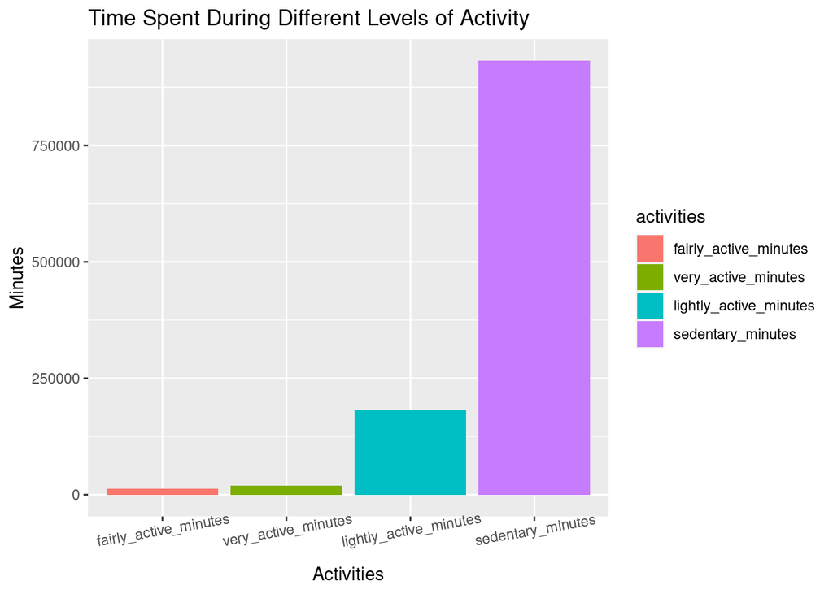

*The highest time of activity was inactivity and second was light activity, leading me to believe most users spend the most of their activity time partaking in light activity*

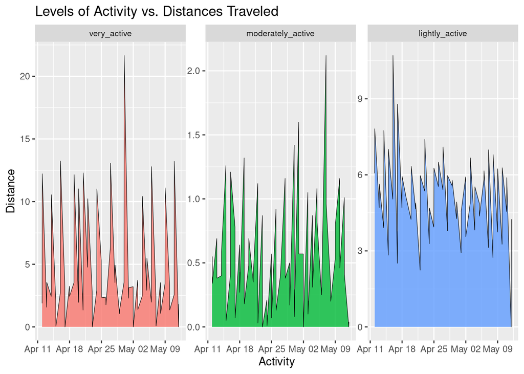

*Getting people to go further thus for spending more time can lead to getting more people to go further and spend more lightly active time. The users that go the shortest distances with light activity also maintain the level and do so consistently daily.*

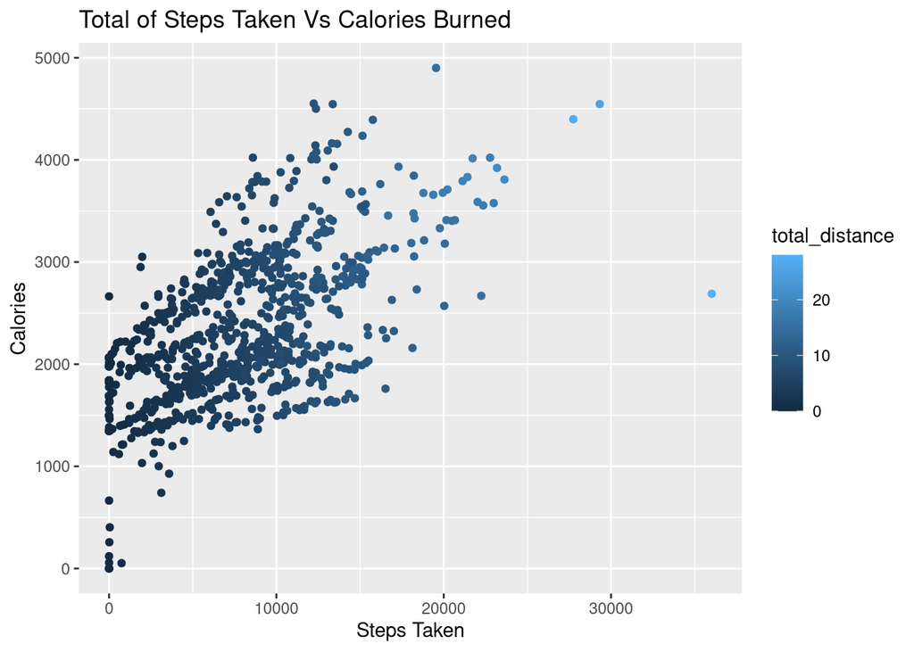

*The more steps and the further the distances people make the more calories get burned. As seen in this chart the number of steps taken doesn’t necessarily mean more calories get burned, even when the outliers are uncounted for.*

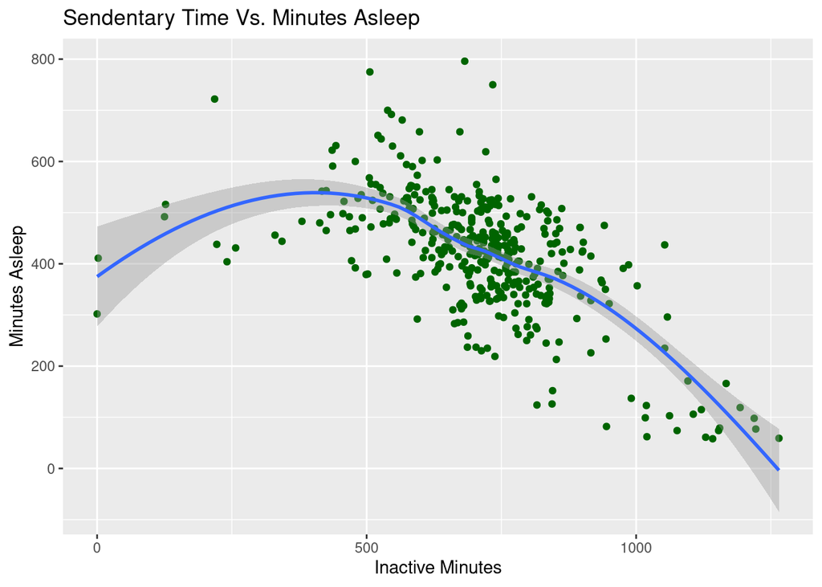

## 5. Final conclusion:

The highest time of activity was inactivity and second was light activity, leading me to believe most users spend most of their activity time partaking in light activity. The number of steps taken doesn’t necessarily mean more calories get burned. I think it’s realistic to assume moderate and light activity that burns calories effectively is something to encourage & will appeal to the average users of the fitbit.